# ScPCA merged report for SCPCP000022

Childhood Cancer Data Lab

**CAUTION: The libraries included in the merged object are NOT integrated or batch-corrected.**

This report includes a brief summary of all libraries included in the merged object for SCPCP000022. This merged object is intended to facilitate downstream analyses across multiple samples.

The libraries included in the merged object are *NOT integrated or batch-corrected*. To conduct any downstream analyses that require batch correction (e.g., UMAP or clustering), batch correction must be performed separately.

# Library information

The merged object summarized in this report is comprised of 50 individual libraries, which are described in the following table.

- `Technology version` indicates which 10x Genomics kit was used for library preparation.
- `Experimental factor ontology` indicates the associated [Experimental factor ontology](https://www.ebi.ac.uk/efo/) (EFO) for the specified 10x version.
- `Suspension type` indicates if the library was prepared from a single-cell (`cell`) or single-nuclei (`nucleus`) suspension.

| Technology version | Experimental factor ontology | Suspension type | Number of libraries |
| --- | --- | --- | --- |
| 10xv2 | EFO:0009899 | cell | 50 |

# Sample information

The merged object summarized in this report contains 25 samples.

## Diagnoses

The following table shows the total number of samples associated with each diagnosis. If a subdiagnosis is available, the total number of samples will be shown for each unique combination of diagnosis and subdiagnosis.

| Diagnosis | Subdiagnosis | Number of samples |
| --- | --- | --- |
| B-cell acute lymphoblastic leukemia | ETV6::RUNX1; t(12;21)(p13.2;q22.1) | 10 |
| T-cell acute lymphoblastic leukemia | NA | 4 |
| Acute myeloid leukemia | NOS | 2 |
| B-cell acute lymphoblastic leukemia | BCR::ABL1-like | 2 |
| B-cell acute lymphoblastic leukemia | BCR::ABL1; t(9;22)(q34.1;q11.2) | 2 |
| B-cell acute lymphoblastic leukemia | hyperdiploid | 2 |
| Acute myeloid leukemia | KMT2A::MLLT3; t(9;11)(p21.3;q23.3) | 1 |
| B-cell acute lymphoblastic leukemia | NOS | 1 |
| B-cell acute lymphoblastic leukemia | TCF3::PBX1; t(1;19)(q23;p13.3) | 1 |

## Disease stage

The following table shows both the diagnosis and at what point during disease progression (`Disease stage`) the sample was taken.

| Diagnosis | Disease stage | Number of samples |
| --- | --- | --- |
| B-cell acute lymphoblastic leukemia | Initial diagnosis | 13 |
| B-cell acute lymphoblastic leukemia | Recurrence | 4 |
| T-cell acute lymphoblastic leukemia | Initial diagnosis | 4 |
| Acute myeloid leukemia | Initial diagnosis | 3 |
| B-cell acute lymphoblastic leukemia | Remission | 1 |

# UMAPs

**CAUTION: The libraries included in the merged object are NOT integrated or batch-corrected.**

In this section, we present UMAPs showing all cells from all libraries included in the merged object. For each library, a separate panel is shown, and cells from that library are colored, while all other cells are gray.

**These merged object UMAP coordinates differ from UMAPs in individual library files.** After individual objects were merged, PCA and UMAP coordinate were recalculated so that each library would contribute equally to the overall scaling. As a consequence, the PCA and UMAP coordinates found in the merged object will differ from the coordinates found in individual libraries.

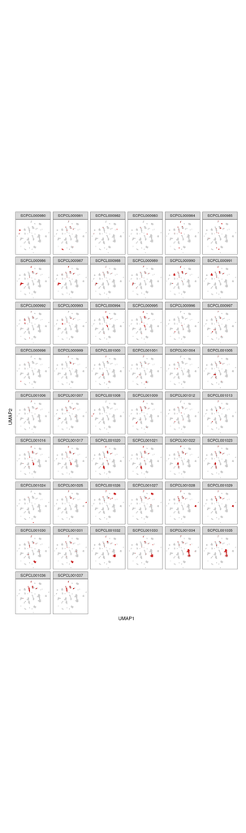